# Statistical Methods for Insurance: Multilevel Models

W6.C2

## Overview of this class

- Fixed effects vs random effects
- Mixed effects models
- Diagnostics

## What is a multilevel model?

- Observations are not independent, but belong to a hierarchy
- Example: individual level demographics (age, gender), and school level information (location, cours offerings, classroom resources)
- Multilevel model enables fitting different types of dependencies

## Fixed vs random

- `Fixed effects` can be used when you know all the categories, e.g. age, gender, smoking status
- `Random effects` are used when not all groups are captured, and we have a random selection of the groups, e.g. individuals (if you have multiple measurements), schools, hospitals

## Mixed effects models - a type of multilevel model

For data organized in \(g\) groups, consider a continuous response linear mixed-effects model (LME model) for each group \(i\), \(i=1, \ldots, g\):

\[\underset{(n_i \times 1)}{{\bf y}_i} = \underset{(n_i \times p)}{{\bf X}_i} \underset{(p \times 1)}{{\boldsymbol \beta}} + \underset{(n_i \times q)}{{\bf Z}_i} \underset{(q \times 1)}{{\bf b}_i} + \underset{(n_i \times 1)}{{\bf \varepsilon}_i}\]

- \({\bf y}_i\) is the vector of outcomes for the \(n_i\) level-1 units in group \(i\)
- \({\bf X}_i\) and \({\bf Z}_i\) are design matrices for the fixed and random effects
- \({\boldsymbol \beta}\) is a vector of \(p\) fixed effects governing the global mean structure
- \({\bf b}_i\) is a vector of \(q\) random effects for between-group covariance
- \({\bf \varepsilon}_i\) is a vector of level-1 error terms for within-group covariance

## Example

- Data: \(radon\), 919 owner-occupied homes in 85 counties of Minnesota. Available in the `HLMdiag` package
- Response: \(log.radon\)
- Fixed: \(storey\) (categorical)
- Covariate: \(uranium\) (quantitative)
- Random: \(county\) (house is a member of county)

```
## Observations: 919
## Variables: 5
## $ log.radon   <dbl> 0.7885, 0.7885, 1.0647, 0.0000, 1.1314, 0.9163, 0....
## $ storey      <int> 1, 0, 0, 0, 0, 0, 0, 0, 0, 0, 0, 0, 0, 0, 0, 0, 0,...
## $ uranium     <dbl> -0.689, -0.689, -0.689, -0.689, -0.847, -0.847, -0...
## $ county      <int> 1, 1, 1, 1, 2, 2, 2, 2, 2, 2, 2, 2, 2, 2, 2, 2, 2,...
## $ county.name <fctr> AITKIN, AITKIN, AITKIN, AITKIN, ANOKA, ANOKA, ANO...
```

## Take a look

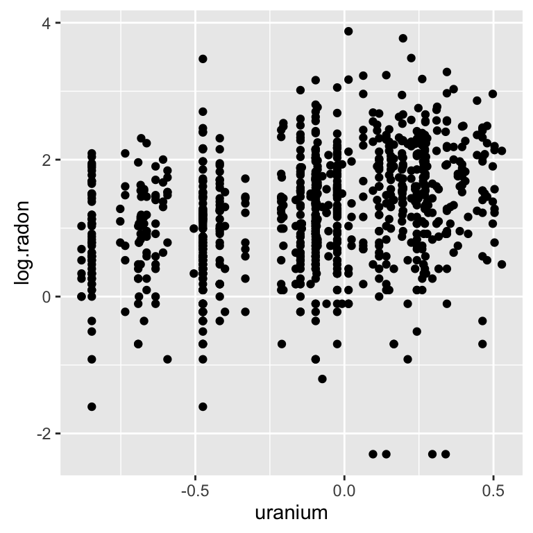

Plot of response vs covariate. What do you see?

## Here's what we see

- Vertical stripes: each county is represented by an average uranium value
- Weak linear association, lots of variation for houses within county
- Four points inline horizontally at the base (be suspicious)
- Some counties only have 2, 3 points
- Scales?

## Pre-processing

- Counties with less than 4 observations removed
- Four flat-line observations should be removed, really suspect these were erroneously coded missing values

## Look again

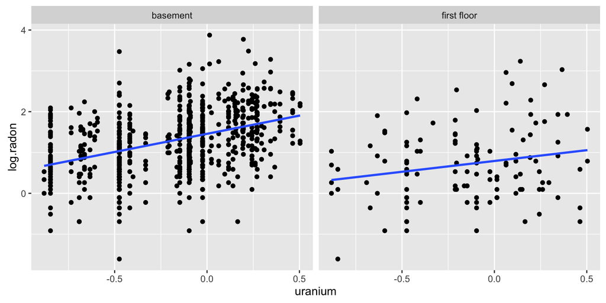

## Fit a simple model

\[log.radon = \beta_0 + \beta_1 storey + \beta_2 uranium + \varepsilon\]

```
##
## Call:
## glm(formula = log.radon ~ storey + uranium, data = radon_sub)
##
## Deviance Residuals:
##     Min       1Q   Median       3Q      Max
## -2.6610  -0.4928   0.0191   0.4745   2.4205
##
## Coefficients:
##                   Estimate Std. Error t value Pr(>|t|)
## (Intercept)         1.4483     0.0313   46.25  < 2e-16 ***
## storeyfirst floor  -0.6112     0.0733   -8.34  3.3e-16 ***
## uranium             0.8359     0.0742   11.26  < 2e-16 ***
## ---
## Signif. codes:  0 '***' 0.001 '**' 0.01 '*' 0.05 '.' 0.1 ' ' 1
##
## (Dispersion parameter for gaussian family taken to be 0.547)
##
##     Null deviance: 538.51  on 795  degrees of freedom
## Residual deviance: 434.02  on 793  degrees of freedom
## AIC: 1784
##
## Number of Fisher Scoring iterations: 2
```

## Your turn

Make a sketch of what this model looks like.

## Fit an interaction term

```
##
## Call:
## glm(formula = log.radon ~ storey * uranium, data = radon_sub)
##
## Deviance Residuals:
##     Min       1Q   Median       3Q      Max
## -2.6445  -0.4898   0.0131   0.4653   2.4369
##
## Coefficients:
##                           Estimate Std. Error t value Pr(>|t|)
## (Intercept)                 1.4580     0.0318   45.91  < 2e-16 ***
## storeyfirst floor          -0.6659     0.0796   -8.37  2.7e-16 ***
## uranium                     0.8909     0.0805   11.07  < 2e-16 ***
## storeyfirst floor:uranium  -0.3620     0.2066   -1.75     0.08 .
## ---
## Signif. codes:  0 '***' 0.001 '**' 0.01 '*' 0.05 '.' 0.1 ' ' 1
##
## (Dispersion parameter for gaussian family taken to be 0.546)
##
##     Null deviance: 538.51  on 795  degrees of freedom
## Residual deviance: 432.34  on 792  degrees of freedom
## AIC: 1783
##
## Number of Fisher Scoring iterations: 2
```

## What does this model look like?

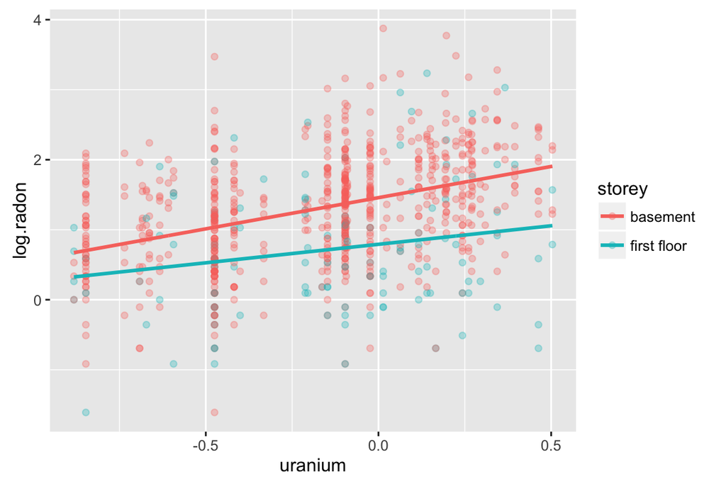

## Your turn

Write down the equation of the fitted model

## Mixed effects model

\[log.radon_{ij} = \beta_0 + \beta_1 storey_{ij} + \beta_2 uranium_i + b_{0i} + b_{1i} storey_{ij} + \varepsilon_{ij}\]

\[~~~ i=1, ..., \#counties; j=1, ..., n_i\]

```r
library(lme4)
radon_lmer <- lmer(log.radon ~ storey + uranium +
  (storey | county.name), data = radon_sub)
summary(radon_lmer)
radon_lmer_fit <- augment(radon_lmer)
```

## Your turn

For the radon data:

- What is \(p\), \(q\), \(g\)?
- And hence \(n_i, i=1, \dots, g\)?

\[log.radon_{ij} = \beta_0 + \beta_1 storey_{ij} + \beta_2 uranium_i + b_{0i} + b_{1i} storey_{ij} + \varepsilon_{ij}\]

\[~~~ i=1, ..., \#counties; j=1, ..., n_i\]

## Examining the model output: fixed effects

```
Fixed effects:
                    Estimate Std. Error t value
(Intercept)          1.48066    0.03856   38.40
storeyfirst floor   -0.59011    0.11246   -5.25
uranium              0.84600    0.09532    8.88
```

How do these compare with the simple linear model estimates?

```
Coefficients:
                  Estimate Std. Error t value Pr(>|t|)
(Intercept)        1.44830    0.03131  46.254  < 2e-16 ***
storeyfirst floor -0.61125    0.07332  -8.337 3.35e-16 ***
uranium            0.83591    0.07422  11.262  < 2e-16 ***
---
Signif. codes:  0 ‘***’ 0.001 ‘**’ 0.01 ‘*’ 0.05 ‘.’ 0.1 ‘ ’ 1
```

## Examining the model output: random effects

```
Random effects:
 Groups      Name                Variance Std.Dev. Corr
 county.name (Intercept)         0.01388  0.1178
             storeyfirst floor   0.22941  0.4790   0.02
 Residual                        0.50694  0.7120
Number of obs: 796, groups:  county.name, 46
```

This is saying that the variance of the estimates for first floor observations is larger than the storey.

## What it looks like

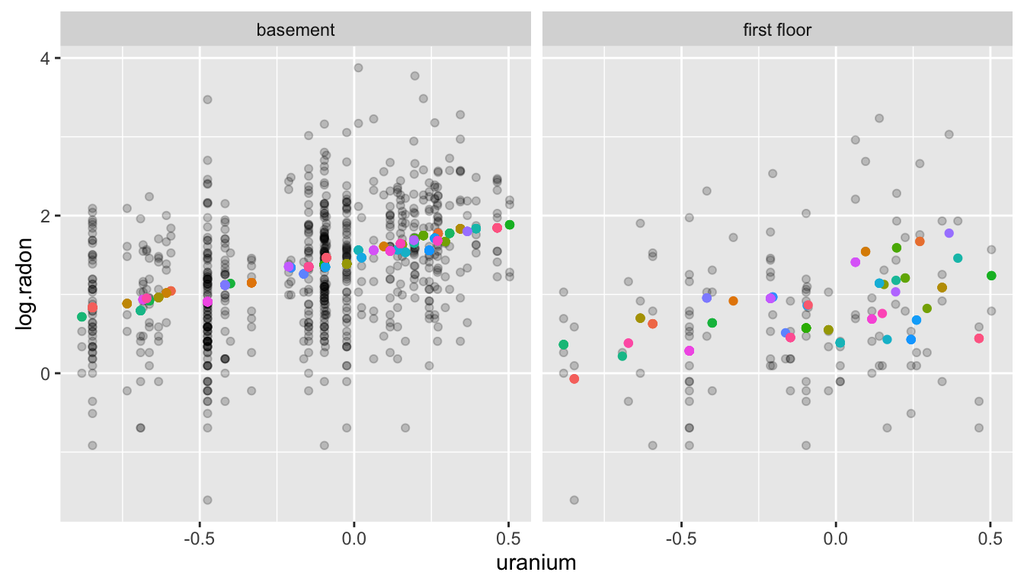

## Or like this

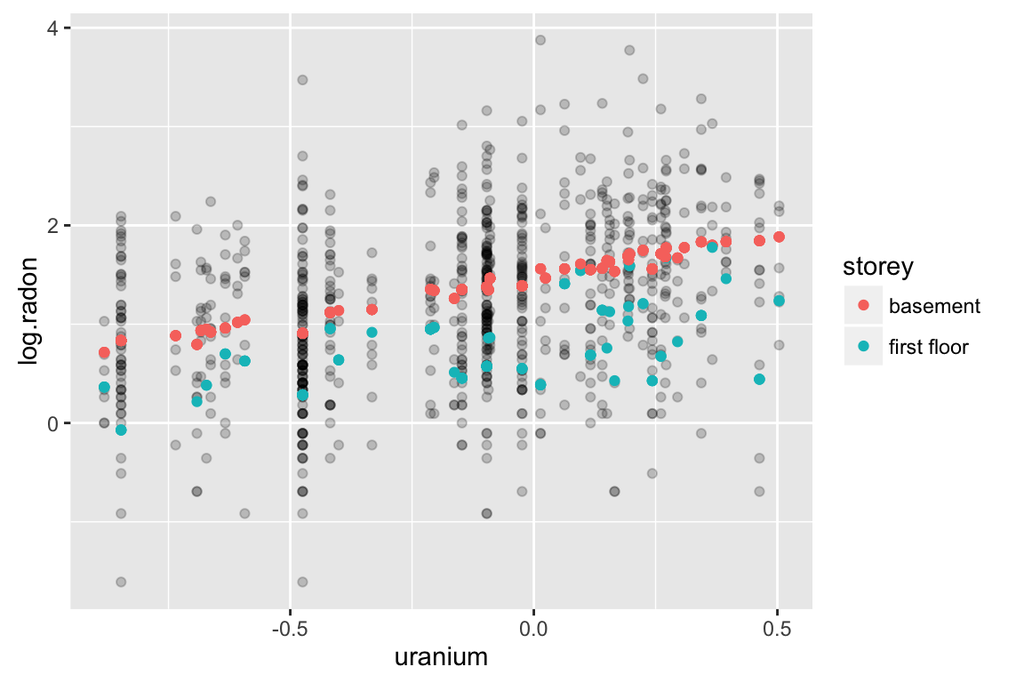

## Your turn

How does the mixed effects model differ from the simple linear model? (Hint: Think about the variance.)

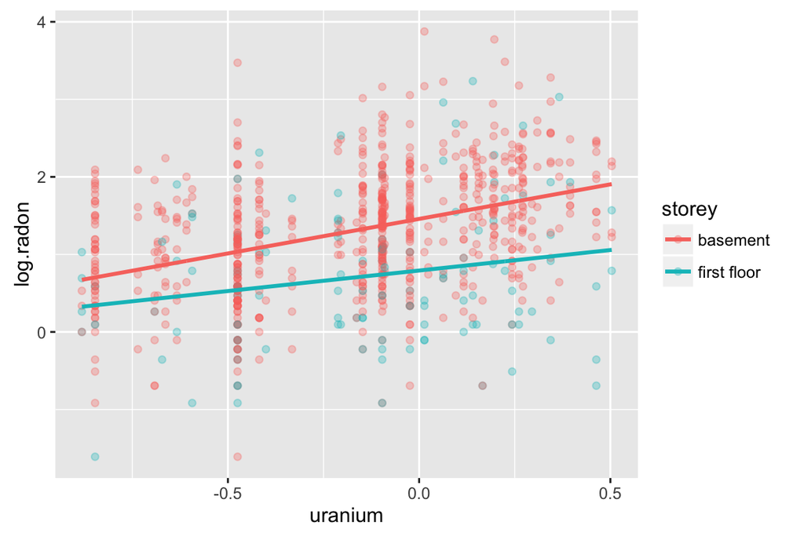

## Assumptions

Recall:

\[\underset{(n_i \times 1)}{{\bf y}_i} = \underset{(n_i \times p)}{{\bf X}_i} \underset{(p \times 1)}{{\boldsymbol \beta}} + \underset{(n_i \times q)}{{\bf Z}_i} \underset{(q \times 1)}{{\bf b}_i} + \underset{(n_i \times 1)}{{\boldsymbol \varepsilon}_i}\]

- \({\bf b}_i\) is a random sample from \(\mathcal{N}({\bf 0}, {\bf D})\) and independent from the level-1 error terms,
- \({\boldsymbol \varepsilon}_i\) follow a \(\mathcal{N}({\bf 0},\sigma^2 {\bf R}_i)\) distribution
- \({\bf D}\) is a positive-definite \(q \times q\) covariance matrix and \({\bf R}_i\) is a positive-definite \(n_i \times n_i\) covariance matrix

## Extract and examine level-1 residuals

\({\boldsymbol \varepsilon}_i \sim \mathcal{N}({\bf 0},\sigma^2 {\bf R}_i)\)

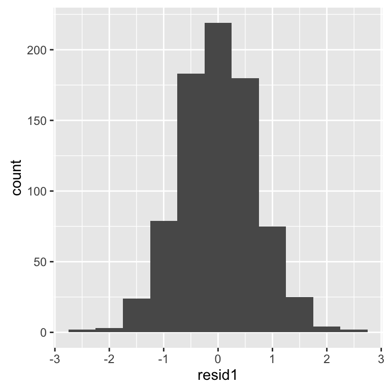

Level-1 (observation level) look normal.

[figure not shown]

## qqplot

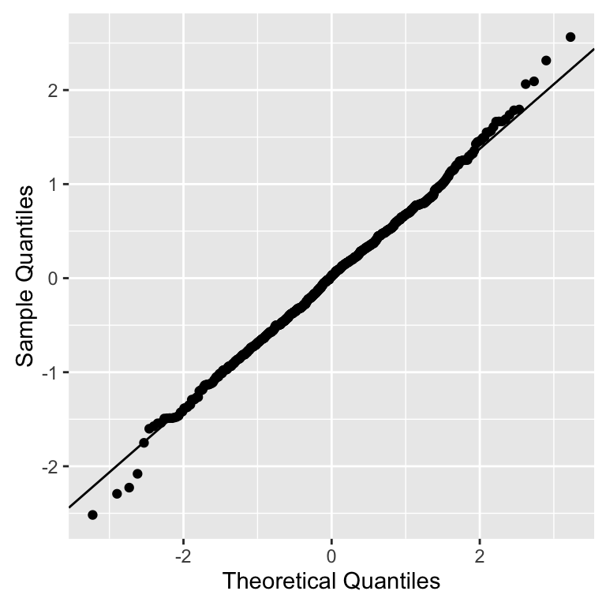

Level-1 (observation level) do look nearly normal.

## Examine within group

Summary statistics

```
## # A tibble: 6 x 4
##   county.name      m     s     n
##        <fctr>  <dbl> <dbl> <int>
## 1       ANOKA  0.051 0.719    52
## 2    BELTRAMI  0.335 0.867     7
## 3  BLUE EARTH  0.152 0.562    14
## 4     CARLTON -0.194 0.651    10
## 5      CARVER  0.322 0.924     5
## 6        CASS  0.383 0.504     5
```

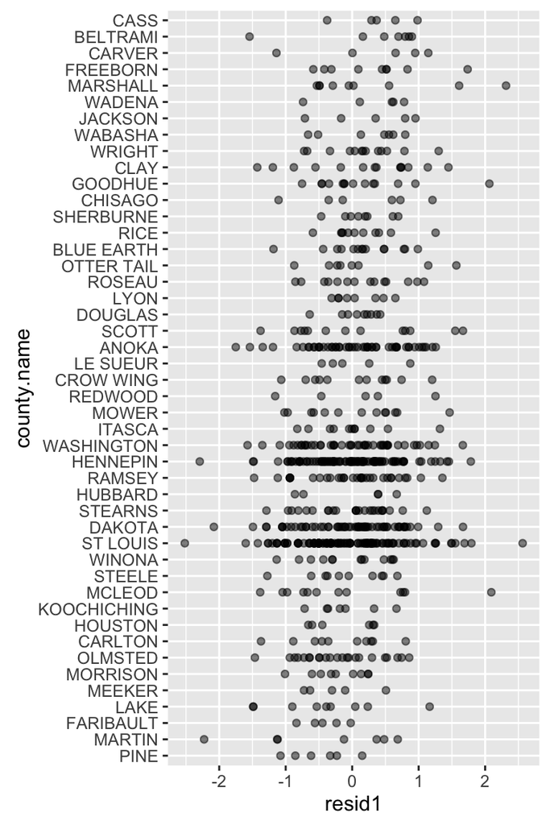

## Learn

There is some difference on average between counties, which means that residuals still have some structure related to the county location.

## Normality tests

Anderson-Darling, Cramer-von Mises, Lilliefors (Kolmogorov-Smirnov)

```
##
##  Anderson-Darling normality test
##
## data:  radon_lmer_fit$resid1
## A = 0.4, p-value = 0.4
```

## Conclusion about level-1 residuals

The assumption:

\[{\boldsymbol \varepsilon}_i \sim \mathcal{N}({\bf 0},\sigma^2 {\bf R}_i)\]

is probably ok, at the worst it is not badly violated.

## Random effects

\[{\bf b}_i \sim \mathcal{N}({\bf 0}, {\bf D}), ~~~ i=1, \dots g\]

where \({\bf D}\) allows for correlation between random effects within group, and these should be independent from the level-1 error

We have both intercepts (basement) and slopes (first floor)

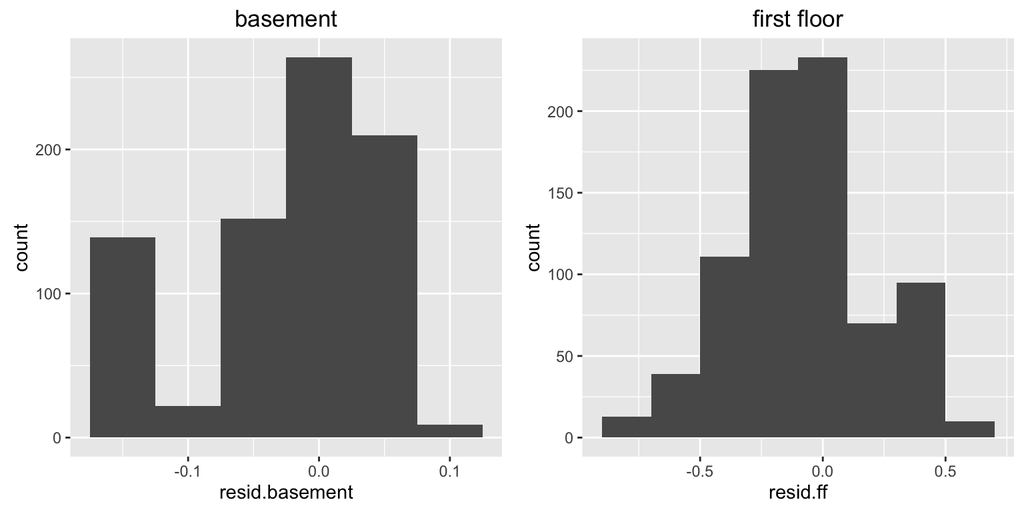

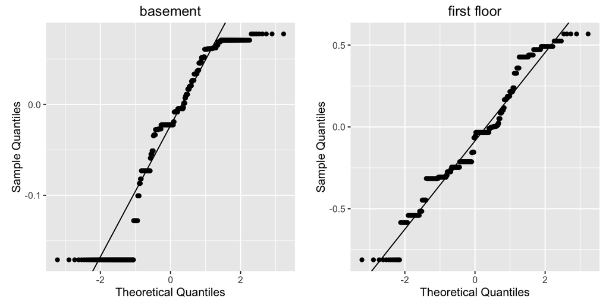

## Should be no correlation

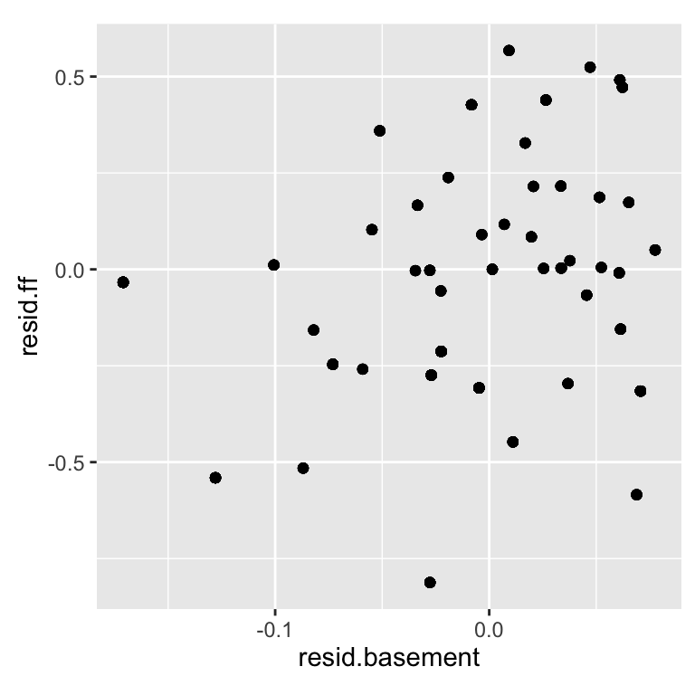

## Fitted vs Observed

Plotting the observed vs fitted values, gives a sense for how much of the response is explained by the model. Here we can see that there is still a lot of unexplained variation.

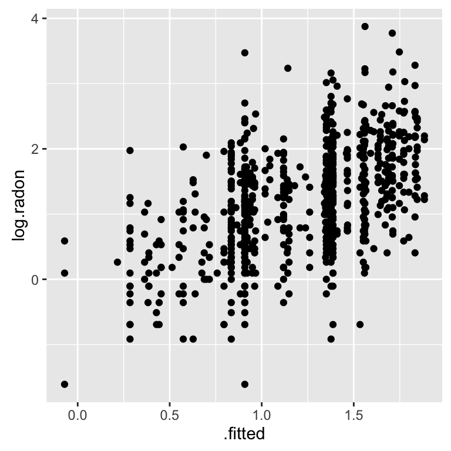

## Goodness of fit

From the linear model

```
##   null.deviance df.null logLik  AIC  BIC deviance df.residual
## 1           539     795   -887 1783 1806      432         792
```

From the random effects model

```
##   sigma logLik  AIC  BIC deviance df.residual
## 1 0.712   -885 1784 1817     1760         789
```

Hmmm… deviance looks strange! Compute sum of squares of residuals instead:

```
## [1] 387
```

Which model is best?

## Influence

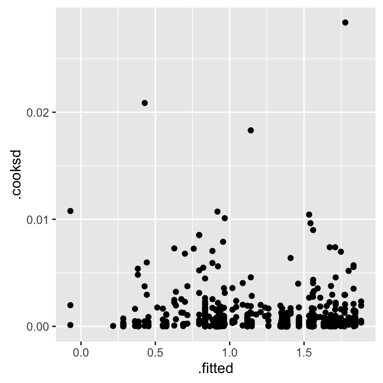

No overly influential observations

## Resources

- [HLMDiag package explanation](https://www.jstatsoft.org/article/view/v056i05)
- [HLM package](https://cran.r-project.org/web/packages/HLMdiag/index.html)

## Share and share alike

This work is licensed under the Creative Commons Attribution-Noncommercial 3.0 United States License. To view a copy of this license, visit http://creativecommons.org/licenses/by-nc/ 3.0/us/ or send a letter to Creative Commons, 171 Second Street, Suite 300, San Francisco, California, 94105, USA.